# University of Chicago Police Department Open Data Analysis

# 1 Introduction

UCPD releases three types of data on their data page. This data is not directly downloadable and was web scraped into a database which was then standardized. The three types of data include *[The Daily Incident Report](https://incidentreports.uchicago.edu/)*, which includes crimes and fires reported to UCPD in its patrol area, *[Traffic Stops](https://incidentreports.uchicago.edu/trafficStops.php)*, and *[Field Interviews](https://incidentreports.uchicago.edu/fieldInterviews.php)*.

# 2 Summary

The University of Chicago Police Department (UCPD) polices about 3.5 square miles of Chicago’s south side. About 50,000 Chicagoans, of which about 50% are African American, live permanently in their patrol area. UCPD’s data shows that African Americans are stopped, searched, and cited at rates higher than any other racial group. Including that:

- Since 2015, **73.3% of traffic stops and 93.7% of street interviews** UCPD conducted were with African Americans
- During traffic stops, African Americans received citations at almost double the rate of non-African Americans **(13.5% vs. 6.9%)**
- UCPD searches **1 out of 39** African American drivers it stops, compared to **1 out of 268** non-African Americans motorists, with **95.0%** of all vehicle searches conducted on African Americans
- Half of all searches conducted on African Americans ended without a citation
- 36 out of 37 traffic stop searches in 2019 were conducted on African American drivers
- In 2019, African Americans were cited at 10.8% and non-African Americans were cited at 6.0%

# 3 Dashboard Overview of Police Actions

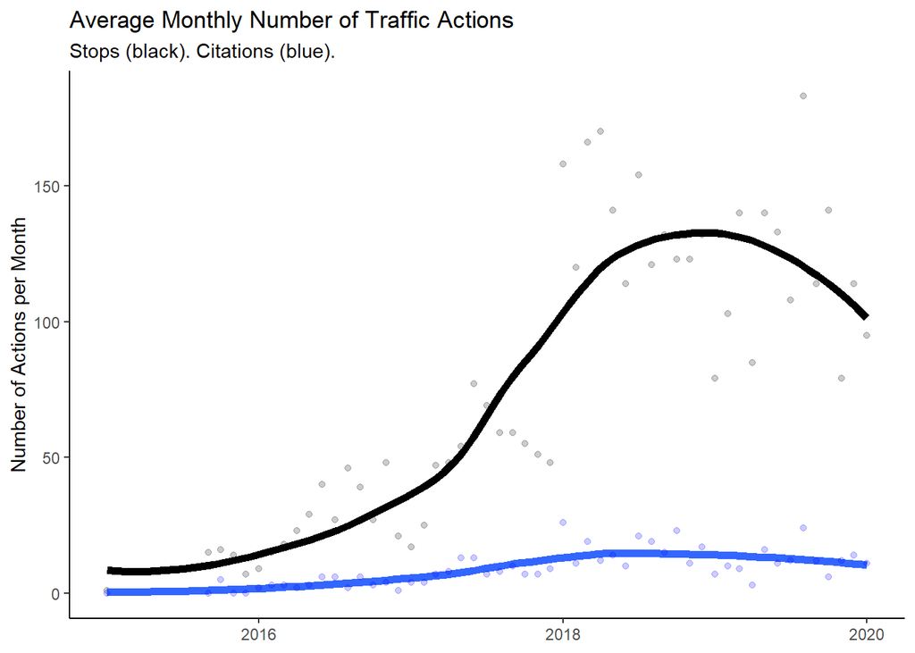

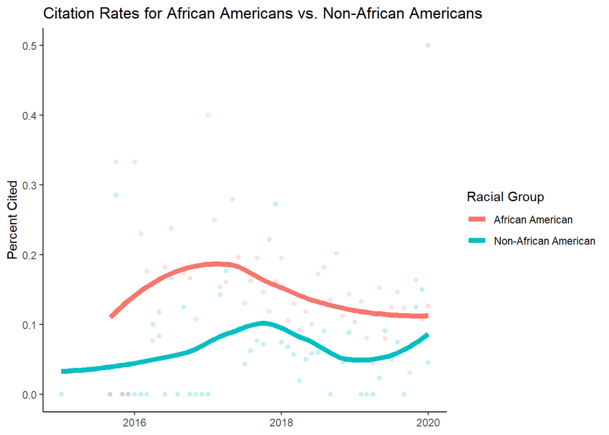

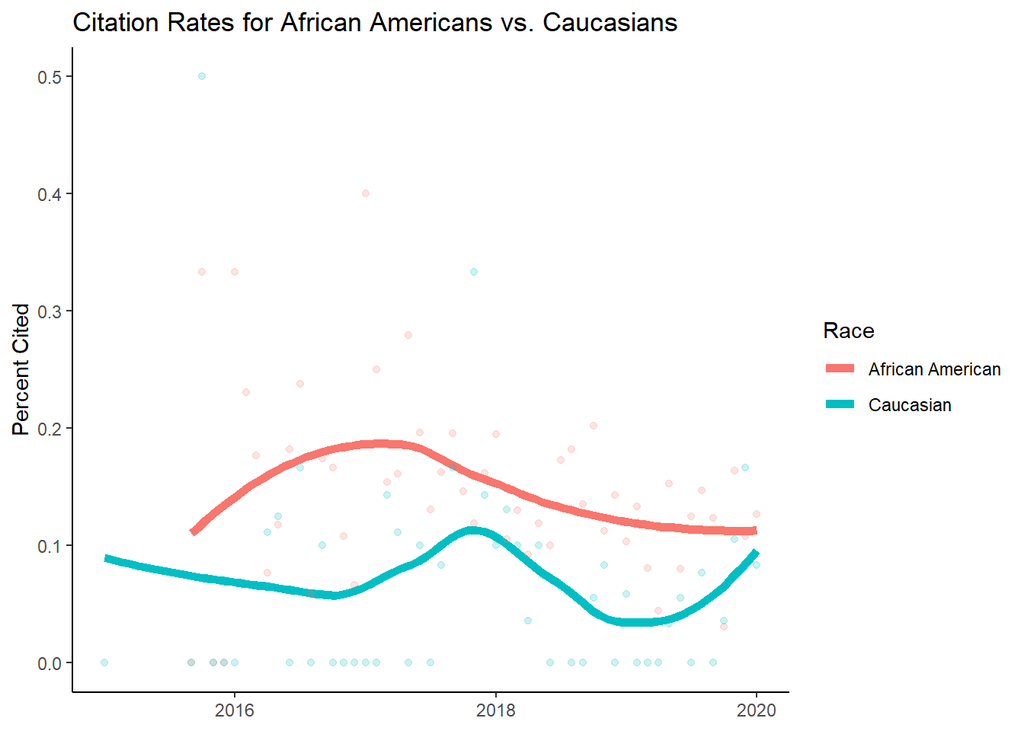

[figure not shown]

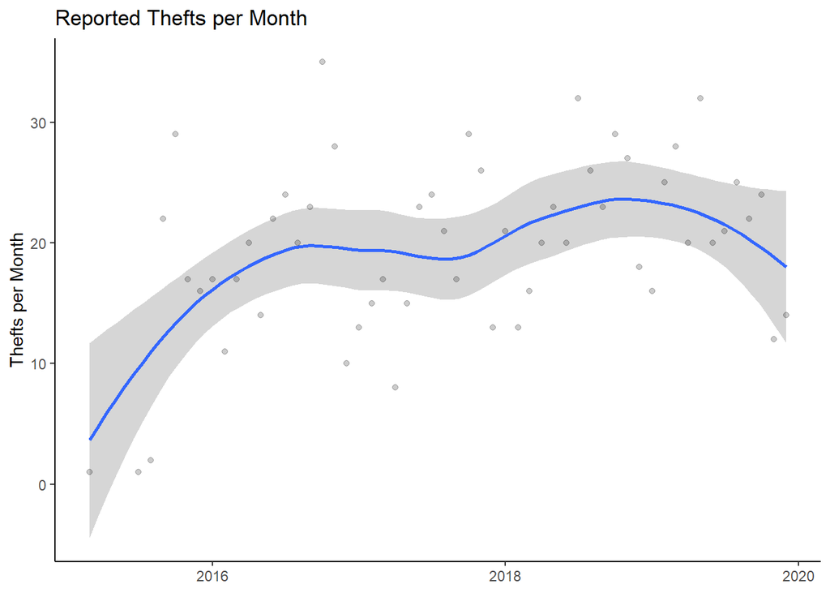

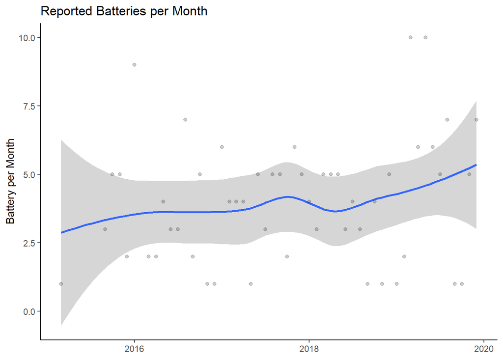

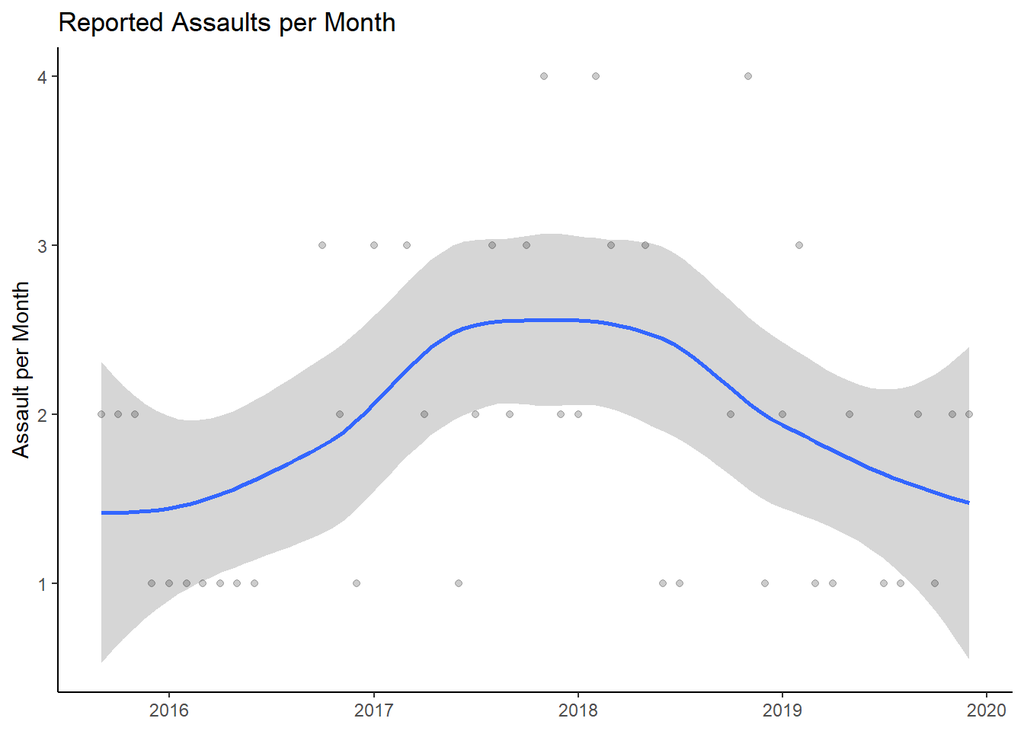

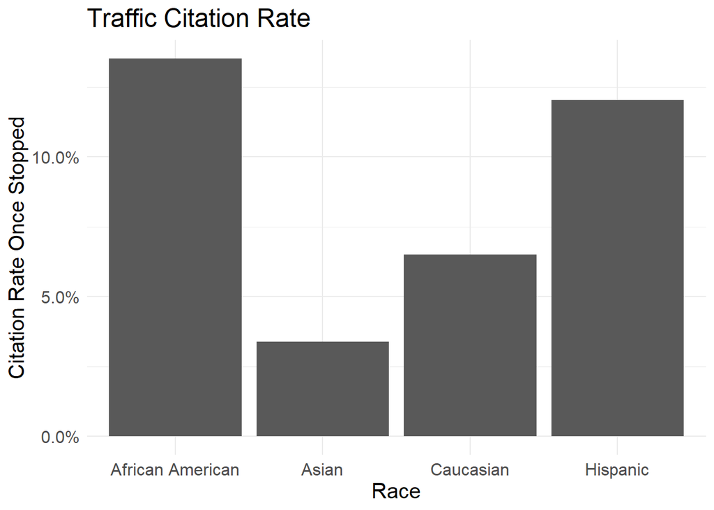

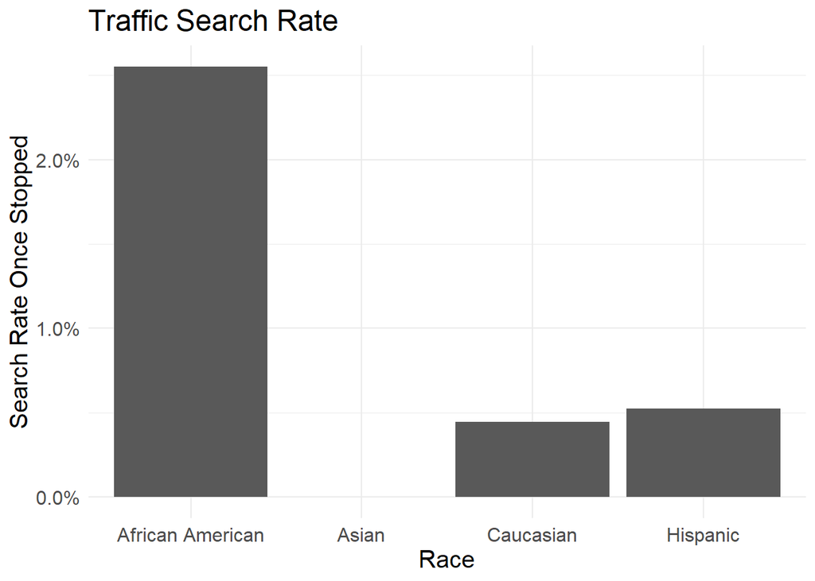

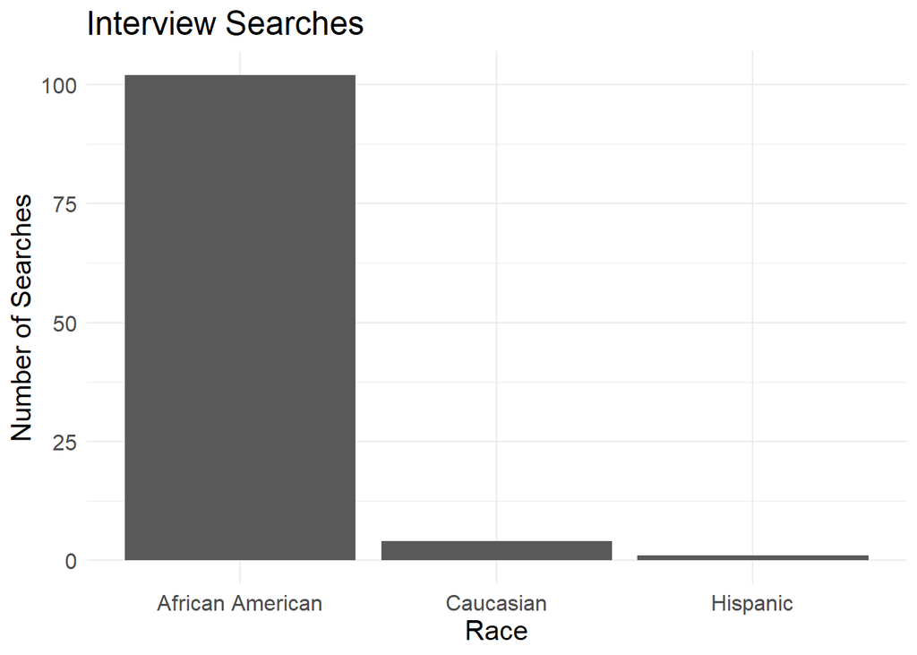

# 4 Summary Tables

## 4.1 Number of interactions with UCPD by Year

Table 1: Traffic Stops

| Year | Total | % African American |
| --- | --- | --- |
| 2015 | 53 | 69.8% |
| 2016 | 342 | 72.2% |
| 2017 | 609 | 71.1% |
| 2018 | 1654 | 72.9% |
| 2019 | 1419 | 75.1% |

Table 2: Incidents

| Year | Total |
| --- | --- |
| 2015 | 337 |
| 2016 | 1095 |
| 2017 | 1104 |
| 2018 | 1246 |
| 2019 | 1226 |

Table 3: Interviews

| Year | Total | % African American |
| --- | --- | --- |
| 2015 | 71 | 90.1% |
| 2016 | 77 | 88.3% |
| 2017 | 101 | 96.0% |
| 2018 | 236 | 94.1% |
| 2019 | 137 | 96.4% |

## 4.2 Traffic Outcomes

Table 4: Traffic Outcomes

| Year | Citation | Warning | Arrest |
| --- | --- | --- | --- |
| 2015 | 5 | 48 | 0 |
| 2016 | 41 | 296 | 5 |
| 2017 | 97 | 511 | 1 |
| 2018 | 198 | 1456 | 0 |
| 2019 | 136 | 1283 | 0 |

Table 5: Traffic Outcomes by Race

| Disposition | Race | Total | Share in Category |
| --- | --- | --- | --- |
| Citation | African American | 403 | 13.5% |
| Citation | Asian | 7 | 3.4% |
| Citation | Caucasian | 44 | 6.5% |
| Citation | Hispanic | 23 | 12.0% |
| Warning | African American | 2577 | 86.5% |
| Warning | Asian | 200 | 96.6% |
| Warning | Caucasian | 633 | 93.5% |
| Warning | Hispanic | 168 | 88.0% |

Table 6: Traffic Search Outcomes by Race

| Search | Race | Total | Share in Category |
| --- | --- | --- | --- |
| No | African American | 2904 | 97.4% |
| No | Asian | 207 | 100.0% |
| No | Caucasian | 674 | 99.6% |
| No | Hispanic | 190 | 99.5% |
| Yes | African American | 76 | 2.6% |
| Yes | Caucasian | 3 | 0.4% |
| Yes | Hispanic | 1 | 0.5% |

Table 7: Traffic Violation Outcomes by Race

| IDOT Classification | African American | Asian | Caucasian | Hispanic |
| --- | --- | --- | --- | --- |
| Equipment | 6.3% | 2.9% | 5.3% | 8.9% |
| Lane Violation | 21.6% | 22.7% | 29.2% | 23.0% |
| license plate/registration | 1.2% | 1.0% | 0.6% | 1.0% |
| moving violation | 6.1% | 5.8% | 5.8% | 4.7% |
| speed | 4.8% | 1.9% | 2.4% | 1.6% |
| Traffic Sign/Signal | 60.0% | 65.7% | 56.7% | 60.7% |

Table 8: Traffic Stop Outcomes by Race and Year

| Year | Race | pct_search | pct_cited | pct_search_cite | pct_search_nocite | pct_warning | count |
| --- | --- | --- | --- | --- | --- | --- | --- |
| 2015 | African American | 3% | 8% | 0% | 3% | 92% | 36 |
| 2015 | Asian | 0% | 0% | 0% | 0% | 100% | 2 |
| 2015 | Caucasian | 0% | 18% | 0% | 0% | 82% | 11 |
| 2015 | Hispanic | 0% | 0% | 0% | 0% | 100% | 2 |
| 2016 | African American | 0% | 14.88% | 0% | 0% | 85.12% | 242 |
| 2016 | Asian | 0% | 0.00% | 0% | 0% | 100.00% | 15 |
| 2016 | Caucasian | 0% | 6.25% | 0% | 0% | 93.75% | 64 |
| 2016 | Hispanic | 0% | 7.14% | 0% | 0% | 92.86% | 14 |
| 2017 | African American | 1% | 18.1% | 0% | 0% | 81.9% | 432 |
| 2017 | Asian | 0% | 6.8% | 0% | 0% | 93.2% | 44 |
| 2017 | Caucasian | 0% | 9.4% | 0% | 0% | 90.6% | 106 |
| 2017 | Hispanic | 4% | 26.1% | 4% | 0% | 73.9% | 23 |
| 2018 | African American | 3% | 14.2% | 2% | 1% | 85.8% | 1205 |
| 2018 | Asian | 0% | 0.0% | 0% | 0% | 100.0% | 87 |
| 2018 | Caucasian | 1% | 5.9% | 1% | 0% | 94.1% | 256 |
| 2018 | Hispanic | 0% | 11.9% | 0% | 0% | 88.1% | 101 |
| 2019 | African American | 3% | 10.8% | 2% | 2% | 89.2% | 1065 |
| 2019 | Asian | 0% | 6.8% | 0% | 0% | 93.2% | 59 |
| 2019 | Caucasian | 0% | 5.4% | 0% | 0% | 94.6% | 240 |
| 2019 | Hispanic | 0% | 7.8% | 0% | 0% | 92.2% | 51 |

## 4.3 Interview Outcomes

Table 9: Interview Initiated By

| Initiated By | 2015 | 2016 | 2017 | 2018 | 2019 |
| --- | --- | --- | --- | --- | --- |
| citizen | 48 | 55 | 61 | 80 | 67 |
| UCPD | 23 | 22 | 40 | 156 | 70 |

Table 10: Interview Search Outcomes by Race

| Search | Race | Total | Share in Category |
| --- | --- | --- | --- |
| No | African American | 481 | 82.5% |
| No | Caucasian | 24 | 85.7% |
| Yes | African American | 102 | 17.5% |
| Yes | Caucasian | 4 | 14.3% |

Table 11: Interview Disposition Outcomes by Race

| Disposition | African American | Caucasian |
| --- | --- | --- |
| arrested | 3.4% | 0% |
| Name Checked/Other | 2.6% | 14.3% |
| referred | 2.2% | 3.6% |
| released | 91.8% | 82.1% |

## 4.4 Incident Outcomes

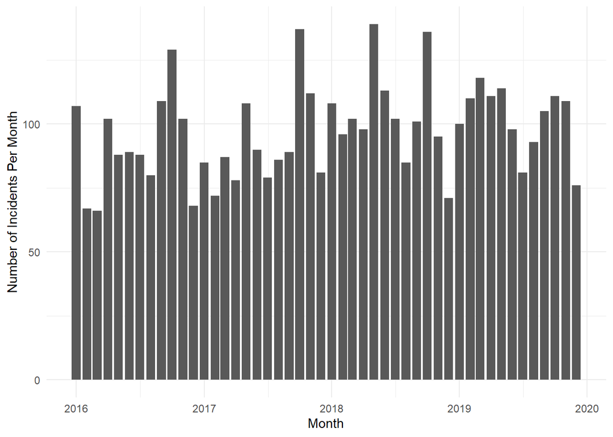

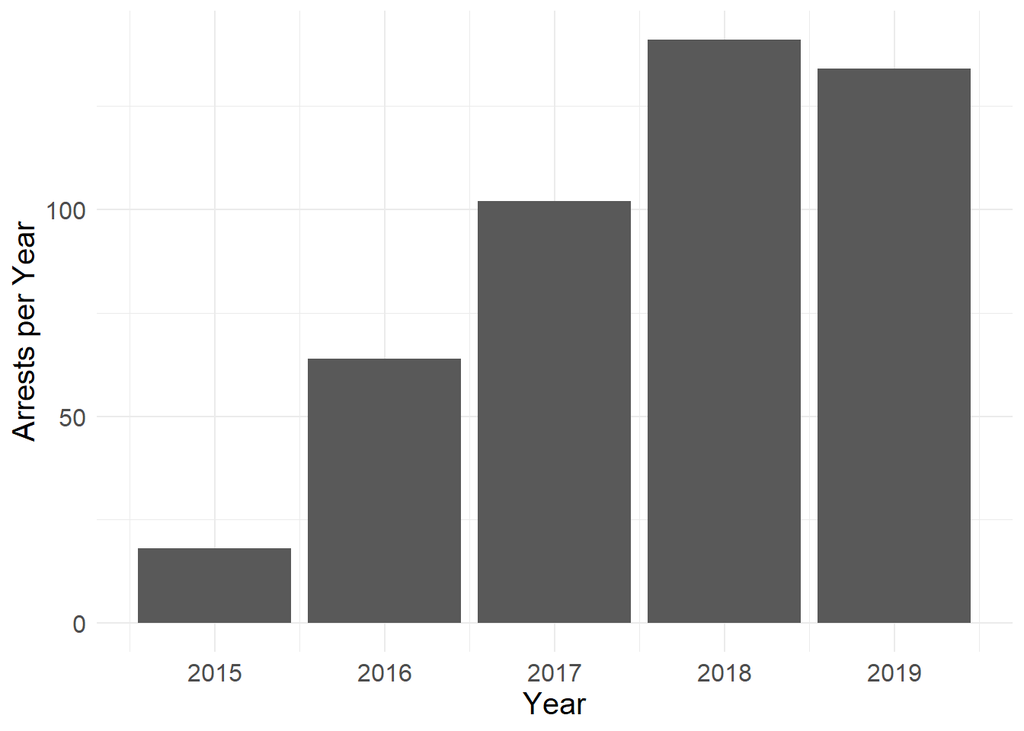

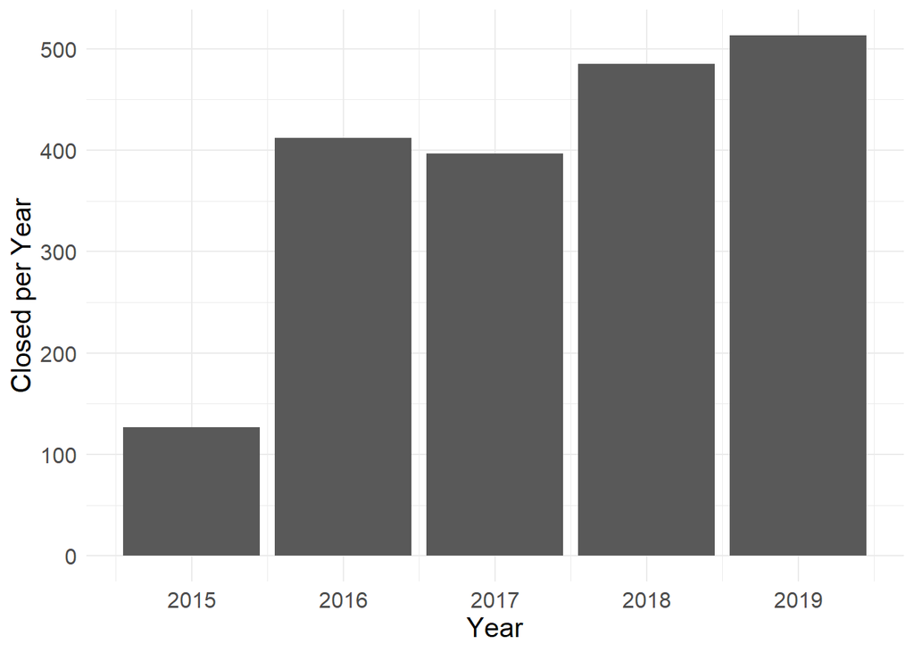

[figure not shown]

Table 12: Incident Outcomes by Year

| Year | arrested | cleared | closed | cpd | open | referred | unfounded |
| --- | --- | --- | --- | --- | --- | --- | --- |
| 2015 | 18 | 12 | 127 | 38 | 106 | 26 | 10 |
| 2016 | 64 | 24 | 412 | 267 | 233 | 76 | 19 |
| 2017 | 102 | 38 | 397 | 254 | 212 | 86 | 15 |
| 2018 | 141 | 27 | 485 | 226 | 271 | 87 | 9 |
| 2019 | 134 | 45 | 513 | 166 | 287 | 67 | 14 |

# 5 UCPD Patrol Area

Table 13: Population in Census Tracts which intersect UCPD Patrol Area

| Total Population | Total White Population | Total Black Population |
| --- | --- | --- |
| 83303 | 20200 | 53244 |

Table 14: Projected Population in UCPD Patrol Area

| Total Population | Total White Population | Total Black Population |
| --- | --- | --- |
| 53726 | 18163 | 27270 |

[interactive chart not shown]

# 6 Github Directory

https://github.com/erhla/UCPD